# Answer-Key: PBR Riders

In the heart of the roaring arenas and under the watchful eyes of thousands, the world of professional bull riding (PBR) unfolds, where grit, skill, and a dash of luck intertwine. We will be building models to investigate how points are achieved by riders, we will dive into the data from the 2023 season of the Touring Pro Division.

```r
library(tidyverse)
riders <- read_csv(here::here("Bull Riding/data/BullRiders.csv"))
```

# 1.

**Fit a model predicting riders Points, what can we notice about the output? Why is this happening? Hint: check data set documentation**

```r
riders %>%
  select(-Rider) %>%
  lm(Points ~ ., data = .) %>%
  summary()
```

```
Call:
lm(formula = Points ~ ., data = .)

Residuals:
       Min         1Q     Median         3Q        Max
-2.749e-12 -1.330e-13 -5.430e-14  1.543e-13  1.227e-11

Coefficients: (1 not defined because of singularities)
                      Estimate Std. Error    t value Pr(>|t|)
(Intercept)          2.880e+02  2.356e-12  1.222e+14  < 2e-16 ***
`Points Back`       -1.000e+00  8.150e-15 -1.227e+14  < 2e-16 ***
Events               2.938e-13  8.755e-14  3.355e+00 0.000881 ***
Outs                -2.449e-13  6.194e-14 -3.953e+00 9.38e-05 ***
Rides                6.650e-13  1.215e-13  5.473e+00 8.58e-08 ***
Buckoffs                    NA         NA         NA       NA
prop.Ridden         -8.528e-15  4.266e-15 -1.999e+00 0.046378 *
`Avg Ride Score`     2.015e-14  1.571e-14  1.282e+00 0.200612
`Highest RideScore` -2.611e-14  1.571e-14 -1.662e+00 0.097470 .
`Avg Buckoff Time`   2.765e-14  3.366e-14  8.220e-01 0.411930
`Round Wins`        -4.725e-13  1.688e-13 -2.800e+00 0.005404 **
`Event Wins`         4.442e-13  2.620e-13  1.695e+00 0.090936 .
`ReRides Taken`     -1.526e-13  9.176e-14 -1.663e+00 0.097140 .
Earnings            -1.628e-17  7.557e-17 -2.160e-01 0.829500
`90Pt Rides`         4.530e-14  7.094e-13  6.400e-02 0.949121
---
Signif. codes:  0 '***' 0.001 '**' 0.01 '*' 0.05 '.' 0.1 ' ' 1

Residual standard error: 7.887e-13 on 342 degrees of freedom
  (1 observation deleted due to missingness)
Multiple R-squared:      1, Adjusted R-squared:      1
F-statistic: 3.439e+28 on 13 and 342 DF,  p-value: < 2.2e-16
```

**Check correlation matrix to help interpret this**

```r
riders %>%
  select(-Rider) %>%
  cor() %>%
  round(2)
```

```
                  Points Points Back Events Outs Rides Buckoffs prop.Ridden
Points              1.00          NA   0.49 0.59  0.91     0.25        0.68
Points Back           NA           1     NA   NA    NA       NA          NA
Events              0.49          NA   1.00 0.96  0.61     0.91        0.15
Outs                0.59          NA   0.96 1.00  0.71     0.91        0.25
Rides               0.91          NA   0.61 0.71  1.00     0.35        0.70
Buckoffs            0.25          NA   0.91 0.91  0.35     1.00       -0.08
prop.Ridden         0.68          NA   0.15 0.25  0.70    -0.08        1.00
Avg Ride Score      0.65          NA   0.43 0.52  0.72     0.27        0.82
Highest RideScore   0.66          NA   0.44 0.53  0.73     0.28        0.82
Avg Buckoff Time    0.00          NA   0.16 0.18  0.04     0.21       -0.20
Round Wins          0.76          NA   0.34 0.42  0.63     0.19        0.47
Event Wins          0.73          NA   0.24 0.31  0.57     0.07        0.48
ReRides Taken       0.11          NA   0.33 0.30  0.15     0.31        0.03
Earnings            0.94          NA   0.39 0.48  0.77     0.18        0.61
90Pt Rides          0.21          NA  -0.03 0.01  0.10    -0.05        0.18
                  Avg Ride Score Highest RideScore Avg Buckoff Time Round Wins
Points                      0.65              0.66             0.00       0.76
Points Back                   NA                NA               NA         NA
Events                      0.43              0.44             0.16       0.34
Outs                        0.52              0.53             0.18       0.42
Rides                       0.72              0.73             0.04       0.63
Buckoffs                    0.27              0.28             0.21       0.19
prop.Ridden                 0.82              0.82            -0.20       0.47
Avg Ride Score              1.00              1.00             0.02       0.48
Highest RideScore           1.00              1.00             0.02       0.49
Avg Buckoff Time            0.02              0.02             1.00       0.07
Round Wins                  0.48              0.49             0.07       1.00
Event Wins                  0.39              0.40            -0.06       0.74
ReRides Taken               0.11              0.11             0.06       0.07
Earnings                    0.57              0.57            -0.04       0.81
90Pt Rides                  0.11              0.11            -0.05       0.30
                  Event Wins ReRides Taken Earnings 90Pt Rides
Points                  0.73          0.11     0.94       0.21
Points Back               NA            NA       NA         NA
Events                  0.24          0.33     0.39      -0.03
Outs                    0.31          0.30     0.48       0.01
Rides                   0.57          0.15     0.77       0.10
Buckoffs                0.07          0.31     0.18      -0.05
prop.Ridden             0.48          0.03     0.61       0.18
Avg Ride Score          0.39          0.11     0.57       0.11
Highest RideScore       0.40          0.11     0.57       0.11
Avg Buckoff Time       -0.06          0.06    -0.04      -0.05
Round Wins              0.74          0.07     0.81       0.30
Event Wins              1.00          0.04     0.76       0.25
ReRides Taken           0.04          1.00     0.08      -0.03
Earnings                0.76          0.08     1.00       0.36
90Pt Rides              0.25         -0.03     0.36       1.00
```

*Rides + buckoff + Outs very collinear, showing evidence of multicollinearity, since two of those variables are used to determine the third, or vice versa. Therefore, when using all three of those in a model 1/3 of those variables will not be included in the final model output due to their strong correlation.*

# Question 2

**Using the riders data set, predict the points of a rider using avg. time for rider to fall off (Avg Buckoff Time), number of rides (Rides), and percent rides ridden (prop. Ridden) as predictors.**

## a

**Fit the Model. Assess models residual plots. What do we see?**

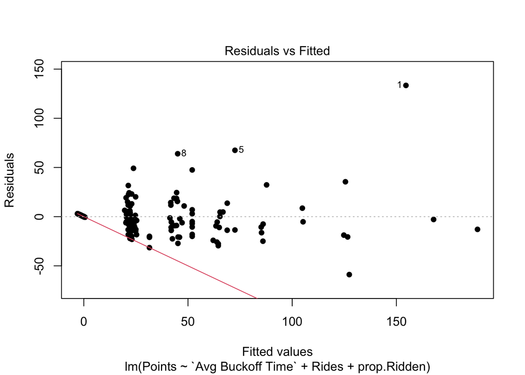

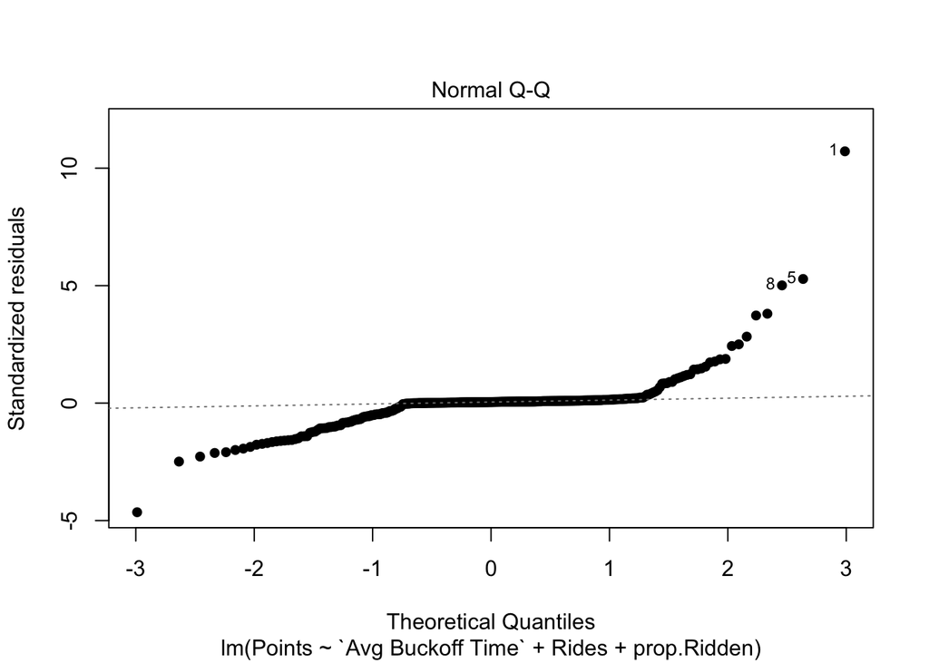

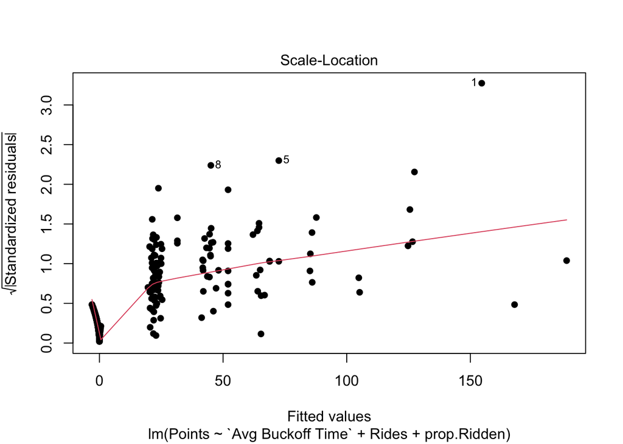

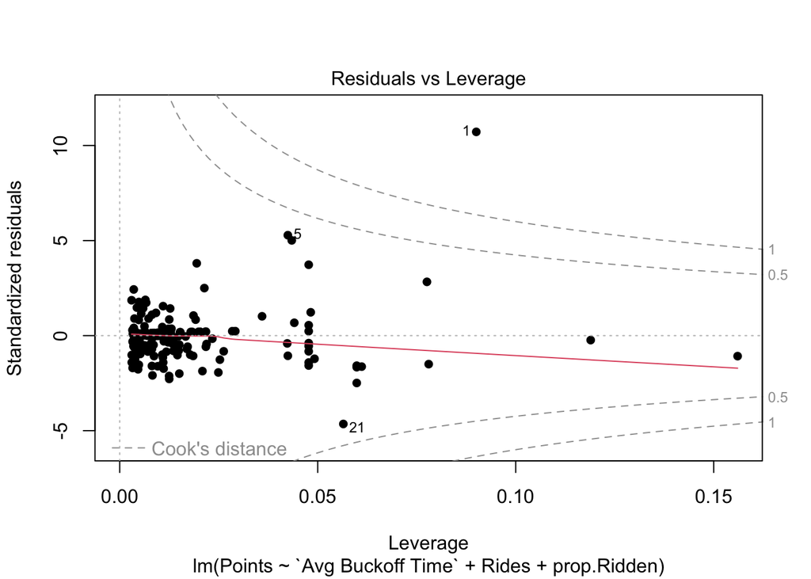

```r
riders %>%
lm(Points ~  `Avg Buckoff Time` + Rides + prop.Ridden, data = .) %>%
  plot(pch=16)
```

*Linearity looks relatively okay. Looking normal Q-Q plot the points are fraying off a at the ends showing potential for issues. The constant variance seems to be a bit all over the place and not linear about zero. Furthermore, looking at cooks distance plot there is significant evidence of an influential point.*

## b

**Does model prove to be significance? Are there any insignificant predictors?**

```r
riders %>%
lm(Points ~  `Avg Buckoff Time` + Rides + prop.Ridden, data = .) %>%
  summary()
```

```
Call:
lm(formula = Points ~ `Avg Buckoff Time` + Rides + prop.Ridden,
    data = .)

Residuals:
    Min      1Q  Median      3Q     Max
-58.894  -0.144   0.573   1.296 133.407

Coefficients:
                   Estimate Std. Error t value Pr(>|t|)
(Intercept)         0.92013    1.97876   0.465   0.6422
`Avg Buckoff Time` -0.53141    0.52316  -1.016   0.3104
Rides              20.51470    0.76454  26.833   <2e-16 ***
prop.Ridden         0.10070    0.03975   2.533   0.0117 *
---
Signif. codes:  0 '***' 0.001 '**' 0.01 '*' 0.05 '.' 0.1 ' ' 1

Residual standard error: 13.05 on 353 degrees of freedom
Multiple R-squared:  0.8297,    Adjusted R-squared:  0.8283
F-statistic: 573.3 on 3 and 353 DF,  p-value: < 2.2e-16
```

*Yes, p-value is approximately zero with F = 573.3 and DF = 353. Yes, when running t-test for the predictors, Avg Buckoff Time has a p-value = 0.3104, which is most insignificant predictor in model*

## c

**Now add an interaction between Avg Buckoff Time and Rides. Record R-code formula here.**

```r
(mod <- lm(Points ~  `Avg Buckoff Time` + Rides + `Avg Buckoff Time`:Rides  + prop.Ridden, data = riders))
```

```
Call:
lm(formula = Points ~ `Avg Buckoff Time` + Rides + `Avg Buckoff Time`:Rides +
    prop.Ridden, data = riders)

Coefficients:
             (Intercept)        `Avg Buckoff Time`                     Rides
                -6.66432                   1.84747                  34.09242
             prop.Ridden  `Avg Buckoff Time`:Rides
                -0.05726                  -3.06554
```

## d

**Test whether having the interaction in the model is significant or not.**

```r
modRed <- lm(Points ~ `Avg Buckoff Time` + Rides + prop.Ridden, data = riders)
modFull <- lm(Points ~ `Avg Buckoff Time` + Rides + `Avg Buckoff Time`:Rides  + prop.Ridden, data = riders)
anova(modRed, modFull, test = "Chisq")
```

```
Analysis of Variance Table

Model 1: Points ~ `Avg Buckoff Time` + Rides + prop.Ridden
Model 2: Points ~ `Avg Buckoff Time` + Rides + `Avg Buckoff Time`:Rides +
    prop.Ridden
  Res.Df   RSS Df Sum of Sq  Pr(>Chi)
1    353 60109
2    352 47707  1     12402 < 2.2e-16 ***
---
Signif. codes:  0 '***' 0.001 '**' 0.01 '*' 0.05 '.' 0.1 ' ' 1
```

# Question 3

**Using ggplot we will be constructing plots to assess the predictors**

## a

**Make a plot so Points ~ Avg Buckoff Time and Rides ~ prop.Ridden. What do we notice?**

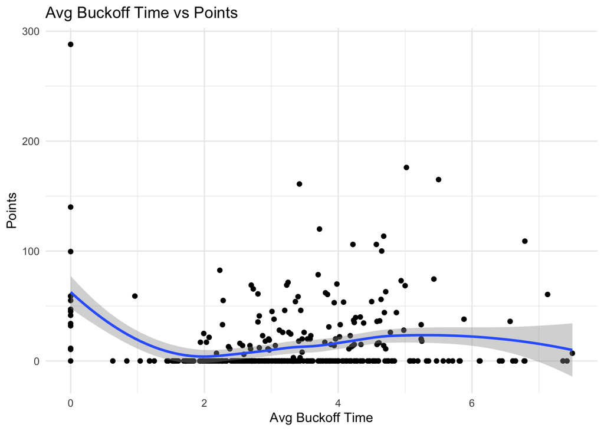

```r
riders %>%
  ggplot(aes(x = `Avg Buckoff Time`, y = Points)) +
  geom_point() +
  geom_smooth() +
  labs(title = "Avg Buckoff Time vs Points") +
  theme_minimal()
```

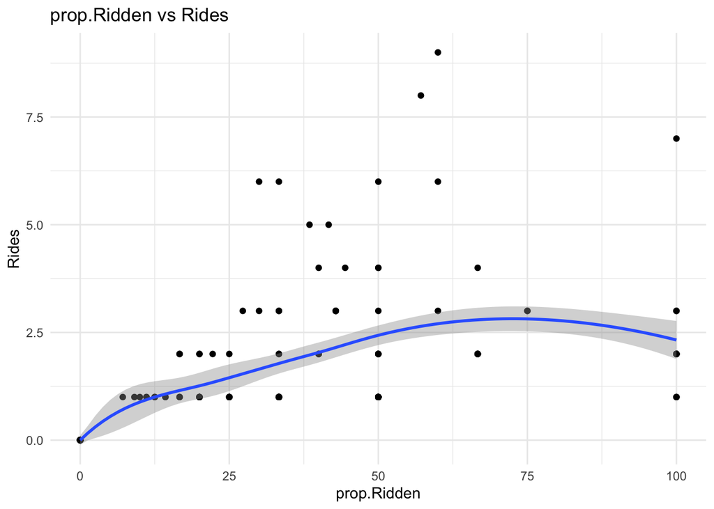

```r
riders %>%
  ggplot(aes(x = prop.Ridden, y = Rides)) +
  geom_point() +
  geom_smooth() +
  labs(title = "prop.Ridden vs Rides") +
  theme_minimal()
```

*Can notice there is a definitely some curvature in the trends of the data points in each of the plots.*

## b

**Based off the outcomes and trends of the plots, what might we consider add to or model from the previous question?**

*Notice the quadratic trends in the plots from the prior part, this means using a quadratic term in our model could be useful.*

## c

**Now, using the model from question 2, add a quadratic term for Avg Buckoff Time. Record the R-code formula here.**

```r
(mod2 <- lm(Points ~  `Avg Buckoff Time` + I(`Avg Buckoff Time`^2) + Rides + `Avg Buckoff Time`:Rides  + prop.Ridden, data = riders))
```

```
Call:
lm(formula = Points ~ `Avg Buckoff Time` + I(`Avg Buckoff Time`^2) +
    Rides + `Avg Buckoff Time`:Rides + prop.Ridden, data = riders)

Coefficients:
             (Intercept)        `Avg Buckoff Time`   I(`Avg Buckoff Time`^2)
                -0.84693                  -1.62775                   0.46843
                   Rides               prop.Ridden  `Avg Buckoff Time`:Rides
                34.01617                  -0.09456                  -2.95148
```

## d

**Test which model, original or transformed, is more effective for the data?**

```r
# mod <- model without quadratic term
# mod2 <- model with quadratic term
anova(mod, mod2)
```

```
Analysis of Variance Table

Model 1: Points ~ `Avg Buckoff Time` + Rides + `Avg Buckoff Time`:Rides +
    prop.Ridden
Model 2: Points ~ `Avg Buckoff Time` + I(`Avg Buckoff Time`^2) + Rides +
    `Avg Buckoff Time`:Rides + prop.Ridden
  Res.Df   RSS Df Sum of Sq      F  Pr(>F)
1    352 47707
2    351 47167  1    539.51 4.0148 0.04587 *
---
Signif. codes:  0 '***' 0.001 '**' 0.01 '*' 0.05 '.' 0.1 ' ' 1
```

# Question 4